# Peer Graded Assignment: PML

Jerry Odia

January 16, 2019

Overview The document is the final report of the Peer Assessment project from Coursera’s course Practical Machine Learning in data science specializtion. The goal of the project is to predict the manner in which 6 participants performed some exercise as described below. This is the “classe” variable in the training set. The machine learning algorithm described here is applied to the 20 test cases available in the test data and the predictions are submitted in appropriate format to the Course Project Prediction Quiz for automated grading.

```r
library(knitr)
library(caret)
```

```r
library(rpart)
library(rpart.plot)
library(rattle)
library(randomForest)
library(corrplot)
library(nlme)
set.seed(33245)
```

Data loading and Cleaning

```r
UrlTrain <- "http://d396qusza40orc.cloudfront.net/predmachlearn/pml-training.csv"
UrlTest  <- "http://d396qusza40orc.cloudfront.net/predmachlearn/pml-testing.csv"
#download the datasets
training <- read.csv(url(UrlTrain))
testing  <- read.csv(url(UrlTest))
#create data partion
inTrain  <- createDataPartition(training$classe, p=0.7, list=FALSE)
TrainSet <- training[inTrain, ]
TestSet  <- training[-inTrain, ]
```

```r
dim(TrainSet)
```

```
## [1] 13737   160
```

```r
dim(TestSet)
```

```
## [1] 5885  160
```

```r
# remove variables that are mostly NA
AllNA    <- sapply(TrainSet, function(x) mean(is.na(x))) > 0.95
TrainSet <- TrainSet[, AllNA==FALSE]
TestSet  <- TestSet[, AllNA==FALSE]
dim(TrainSet)
```

```
## [1] 13737    93
```

```r
# remove Near Zero variables
NZV <- nearZeroVar(TrainSet)
TrainSet <- TrainSet[, -NZV]
TestSet  <- TestSet[, -NZV]
dim(TrainSet)
```

```
## [1] 13737    59
```

```r
TrainSet<-TrainSet[,-c(2,5)]
TestSet<-TestSet[,-c(2,5)]
```

Standardize by preProcessing

```r
preobj<-preProcess(TrainSet,method=c("center","scale"))
TrainSetS<-predict(preobj,TrainSet)
TestSetS<-predict(preobj,TestSet)
```

Correlation Analysis

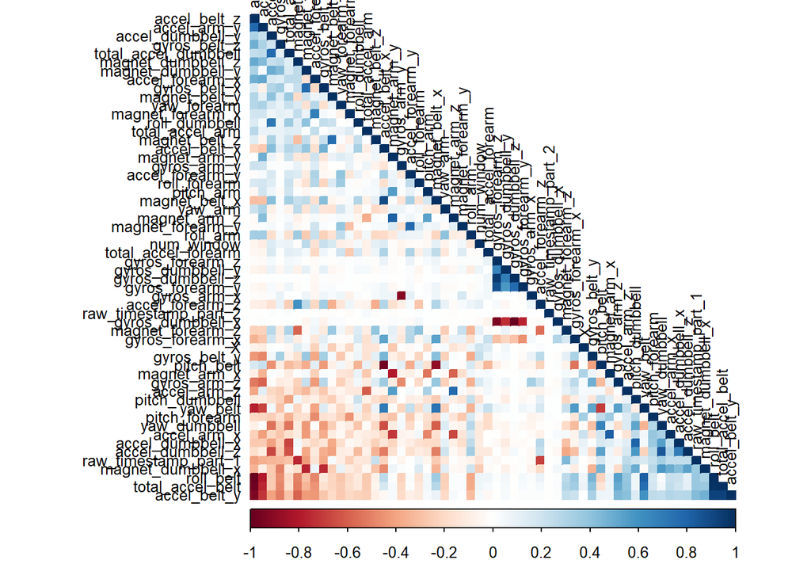

```r
corMatrix<-cor(TrainSetS[,-57])
corrplot(corMatrix,order="FPC",method="color",type = "lower",tl.cex=0.8, tl.col = rgb(0,0,0))
```

Prediction Modelling Three methods(models) will be trained using the TrainSets, the one with highest accuracy when applied to the TestSets will be used for the quiz predictions. The methods are: Random Forests, Decision Tree and Generalized Boosted Model, as described below. A Confusion Matrix is plotted at the end of each analysis to better visualize the accuracy of the models.

```r
# Random Forest model fit
set.seed(33245)
controlRF <- trainControl(method="cv", number=3, verboseIter=FALSE)
modFitRF <- train(classe ~ ., data=TrainSetS, method="rf",trControl=controlRF)
modFitRF$finalModel
```

```
##
## Call:
##  randomForest(x = x, y = y, mtry = param$mtry)
##                Type of random forest: classification
##                      Number of trees: 500
## No. of variables tried at each split: 29
##
##         OOB estimate of  error rate: 0%
## Confusion matrix:
##      A    B    C    D    E class.error
## A 3906    0    0    0    0           0
## B    0 2658    0    0    0           0
## C    0    0 2396    0    0           0
## D    0    0    0 2252    0           0
## E    0    0    0    0 2525           0
```

```r
# prediction on Test dataset
predictRF <- predict(modFitRF, newdata=TestSetS)
confMatRF <- confusionMatrix(predictRF, TestSetS$classe)
confMatRF
```

```
## Confusion Matrix and Statistics
##
##           Reference
## Prediction    A    B    C    D    E
##          A 1674    0    0    0    0
##          B    0 1139    1    0    0
##          C    0    0 1025    0    0
##          D    0    0    0  964    0
##          E    0    0    0    0 1082
##
## Overall Statistics
##
##                Accuracy : 0.9998
##                  95% CI : (0.9991, 1)
##     No Information Rate : 0.2845
##     P-Value [Acc > NIR] : < 2.2e-16
##
##                   Kappa : 0.9998
##  Mcnemar's Test P-Value : NA
##
## Statistics by Class:
##
##                      Class: A Class: B Class: C Class: D Class: E
## Sensitivity            1.0000   1.0000   0.9990   1.0000   1.0000
## Specificity            1.0000   0.9998   1.0000   1.0000   1.0000
## Pos Pred Value         1.0000   0.9991   1.0000   1.0000   1.0000
## Neg Pred Value         1.0000   1.0000   0.9998   1.0000   1.0000
## Prevalence             0.2845   0.1935   0.1743   0.1638   0.1839
## Detection Rate         0.2845   0.1935   0.1742   0.1638   0.1839
## Detection Prevalence   0.2845   0.1937   0.1742   0.1638   0.1839
## Balanced Accuracy      1.0000   0.9999   0.9995   1.0000   1.0000
```

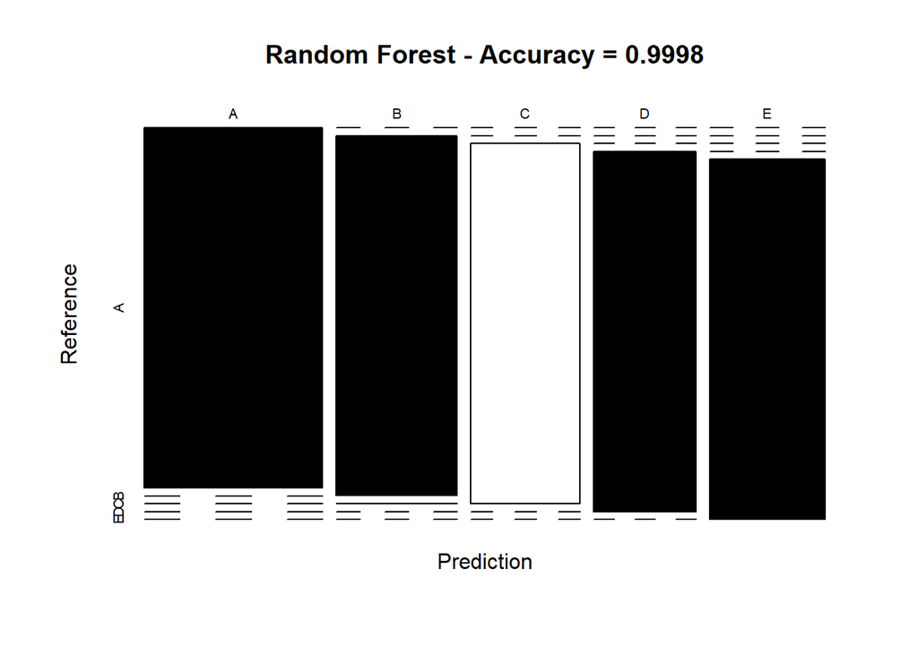

```r
#plot matrix results
plot(confMatRF$table, col = confMatRF$byClass,
     main = paste("Random Forest - Accuracy =",round(confMatRF$overall['Accuracy'], 4)))
```

[figure not shown]

```r
#Decision Trees Model Fit
set.seed(33245)
modFitDT<-rpart(classe~.,data=TrainSetS,method="class")
fancyRpartPlot(modFitDT)
```

```r
#Apply Model to Testdata
predictDT <- predict(modFitDT, newdata=TestSetS, type="class")
confMatDT<-confusionMatrix(predictDT,TestSetS$classe)
confMatDT
```

```
## Confusion Matrix and Statistics
##
##           Reference
## Prediction    A    B    C    D    E
##          A 1673    0    0    0    0
##          B    1 1139    0    0    0
##          C    0    0 1026    0    0
##          D    0    0    0  964    0
##          E    0    0    0    0 1082
##
## Overall Statistics
##
##                Accuracy : 0.9998
##                  95% CI : (0.9991, 1)
##     No Information Rate : 0.2845
##     P-Value [Acc > NIR] : < 2.2e-16
##
##                   Kappa : 0.9998
##  Mcnemar's Test P-Value : NA
##
## Statistics by Class:
##
##                      Class: A Class: B Class: C Class: D Class: E
## Sensitivity            0.9994   1.0000   1.0000   1.0000   1.0000
## Specificity            1.0000   0.9998   1.0000   1.0000   1.0000
## Pos Pred Value         1.0000   0.9991   1.0000   1.0000   1.0000
## Neg Pred Value         0.9998   1.0000   1.0000   1.0000   1.0000
## Prevalence             0.2845   0.1935   0.1743   0.1638   0.1839
## Detection Rate         0.2843   0.1935   0.1743   0.1638   0.1839
## Detection Prevalence   0.2843   0.1937   0.1743   0.1638   0.1839
## Balanced Accuracy      0.9997   0.9999   1.0000   1.0000   1.0000
```

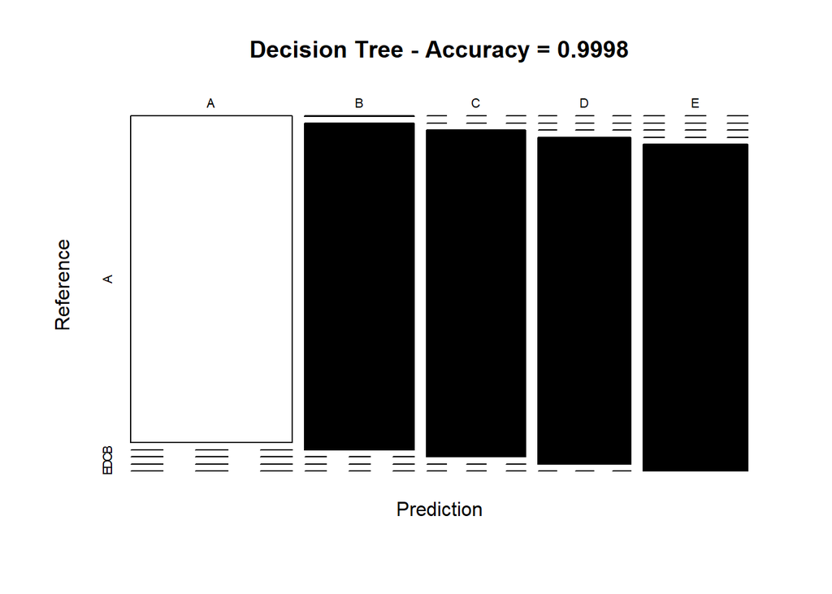

```r
#plot matrix results
plot(confMatDT$table, col = confMatDT$byClass,
     main = paste("Decision Tree - Accuracy =",
                  round(confMatDT$overall['Accuracy'], 4)))
```

```r
# Generalized Boosted Model Fit
set.seed(33245)
controlGBM <- trainControl(method = "repeatedcv", number = 5, repeats = 1)
modFitGBM  <- train(classe ~ ., data=TrainSetS, method = "gbm",trControl = controlGBM, verbose = FALSE)
modFitGBM$finalModel
```

```
## A gradient boosted model with multinomial loss function.
## 50 iterations were performed.
## There were 56 predictors of which 1 had non-zero influence.
```

```r
#prediction on Test dataset
predictGBM <- predict(modFitGBM, newdata=TestSetS)
confMatGBM <- confusionMatrix(predictGBM, TestSetS$classe)
confMatGBM
```

```
## Confusion Matrix and Statistics
##
##           Reference
## Prediction    A    B    C    D    E
##          A 1673    0    0    0    0
##          B    1 1139    0    0    0
##          C    0    0 1026    0    0
##          D    0    0    0  964    0
##          E    0    0    0    0 1082
##
## Overall Statistics
##
##                Accuracy : 0.9998
##                  95% CI : (0.9991, 1)
##     No Information Rate : 0.2845
##     P-Value [Acc > NIR] : < 2.2e-16
##
##                   Kappa : 0.9998
##  Mcnemar's Test P-Value : NA
##
## Statistics by Class:
##
##                      Class: A Class: B Class: C Class: D Class: E
## Sensitivity            0.9994   1.0000   1.0000   1.0000   1.0000
## Specificity            1.0000   0.9998   1.0000   1.0000   1.0000
## Pos Pred Value         1.0000   0.9991   1.0000   1.0000   1.0000
## Neg Pred Value         0.9998   1.0000   1.0000   1.0000   1.0000
## Prevalence             0.2845   0.1935   0.1743   0.1638   0.1839
## Detection Rate         0.2843   0.1935   0.1743   0.1638   0.1839
## Detection Prevalence   0.2843   0.1937   0.1743   0.1638   0.1839
## Balanced Accuracy      0.9997   0.9999   1.0000   1.0000   1.0000
```

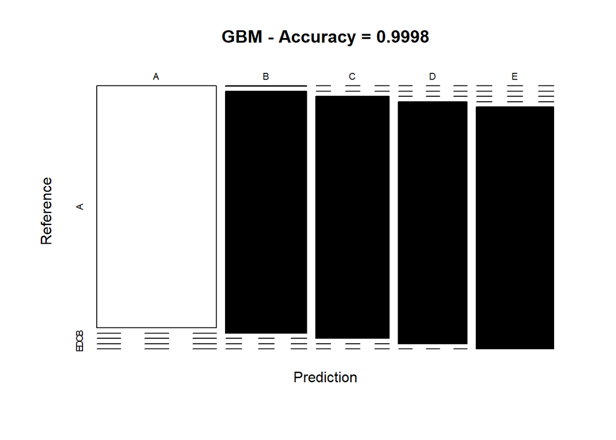

```r
#plot matrix results
plot(confMatGBM$table, col = confMatGBM$byClass,
     main = paste("GBM - Accuracy =", round(confMatGBM$overall['Accuracy'], 4)))
```

Applying the selected Model to the Test Data Accuracy of the 3 models are: Random Forest=0.9998 Decision Tree=0.9998 GBM=0.9998 In this case, since all 3 models have thesame accuracy, any one of them can be selected. GBM is selected

```r
predictTEST <- predict(modFitGBM, newdata=testing)
predictTEST
```

```
##  [1] D E E E E E E E E E E E E E E E E E E E
## Levels: A B C D E
```